# ENM Day 1: Introduction

# 1 Aggregating Rasters

Loading libraries

```r
library(raster)
library(rgdal)
```

```r
library(maptools)
library(here)
```

Set your paths set working diesctory: old way setwd(“/home/neftali/Documents/lectures/enm/intro”) Set path to layers

```r
## path to original layers
path2layers<- here("layers", "lidar","original_vars")
## path to aggregated layers
path2agglayers<-here("layers", "lidar","agregated_vars")
```

## 1.1 Load environmental variables

```r
layers<-list.files(path=path2layers,pattern='asc',full.names=TRUE)
```

## 1.2 Join all rasters in a single object

```r
egv<-stack(layers)
```

- check the structure of the rasters

```r
print(egv)
```

```
## class      : RasterStack
## dimensions : 268, 197, 52796, 6  (nrow, ncol, ncell, nlayers)
## resolution : 1, 1  (x, y)
## extent     : 587674, 587871, 4631485, 4631753  (xmin, xmax, ymin, ymax)
## crs        : NA
## names      : asp, mda, mds, mdt, rug, slp
```

- check descriptive statistics of the rasters

```r
summary(egv)
```

```
##             asp mda  mds  mdt    rug       slp
## Min.    0.00060  -1 1081 1080 0.0136  0.051200
## 1st Qu. 1.83050   0 1096 1095 0.3593  7.835075
## Median  2.33725   0 1112 1111 0.6496 14.404300
## 3rd Qu. 3.44585   1 1121 1120 1.0942 23.719151
## Max.    6.28260  22 1133 1131 6.0195 67.279900
## NA's    0.00000   0    0    0 0.0000  0.000000
```

## 1.3 Plot the stack

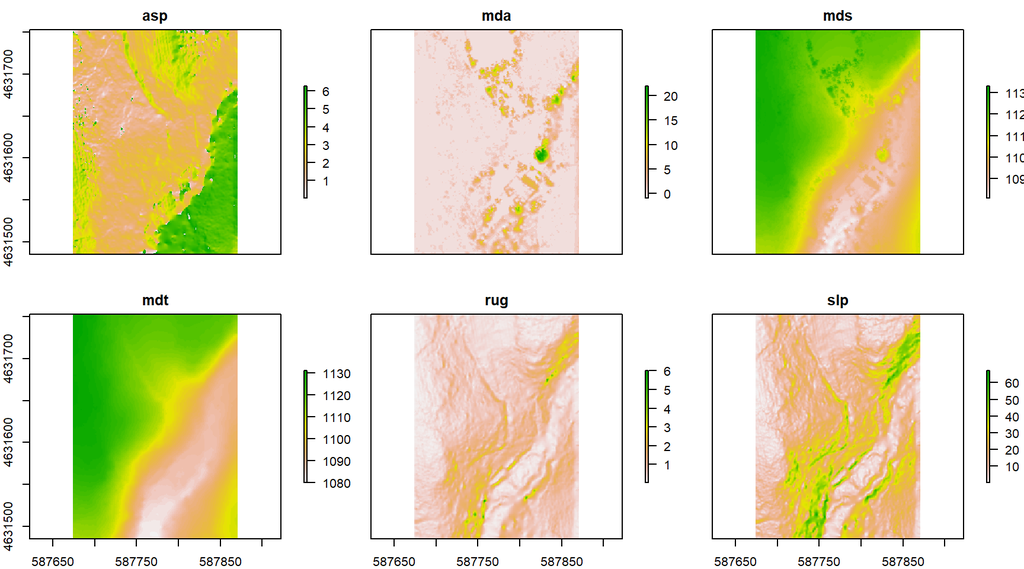

```r
plot(egv)
```

## 1.4 Aggregate raster

‘aggregate()’ input parameters: object; number of pixels to aggregate; aggregation function

```r
agg<-aggregate(egv,10,fun=mean)
```

- check the structure of the aggregated rasters

```r
print(agg)
```

```
## class      : RasterBrick
## dimensions : 27, 20, 540, 6  (nrow, ncol, ncell, nlayers)
## resolution : 10, 10  (x, y)
## extent     : 587674, 587874, 4631483, 4631753  (xmin, xmax, ymin, ymax)
## crs        : NA
## source     : memory
## names      :         asp,         mda,         mds,         mdt,         rug,         slp
## min values :    0.868781,    0.000000, 1082.225000, 1080.525000,    0.108710,    2.028029
## max values :    5.561549,   15.010000, 1131.360000, 1131.000000,    2.564869,   45.348747
```

- check descriptive statistics of the aggregated rasters

```r
summary(agg)
```

```
##             [,1]  [,2]     [,3]     [,4]      [,5]      [,6]
## Min.    0.868781  0.00 1082.225 1080.525 0.1087100  2.028029
## 1st Qu. 1.913474  0.05 1096.248 1094.740 0.4210865  9.184954
## Median  2.382287  0.26 1111.180 1110.575 0.6727450 14.748836
## 3rd Qu. 3.329767  1.29 1120.943 1120.302 1.1279975 23.781116
## Max.    5.561549 15.01 1131.360 1131.000 2.5648690 45.348747
## NA's    0.000000  0.00    0.000    0.000 0.0000000  0.000000
```

## 1.5 Loop to export sequentially aggregated stack

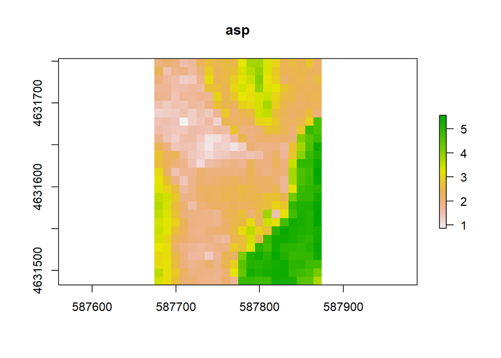

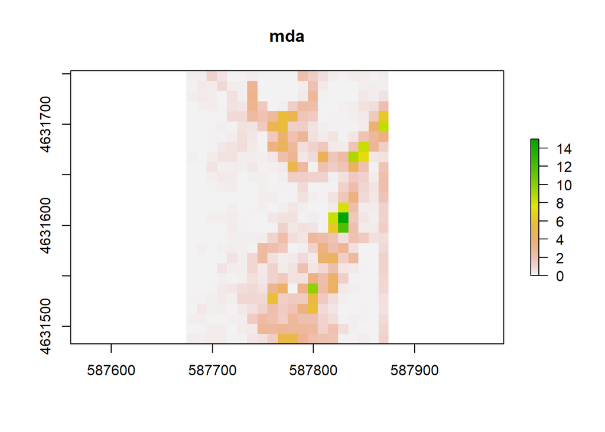

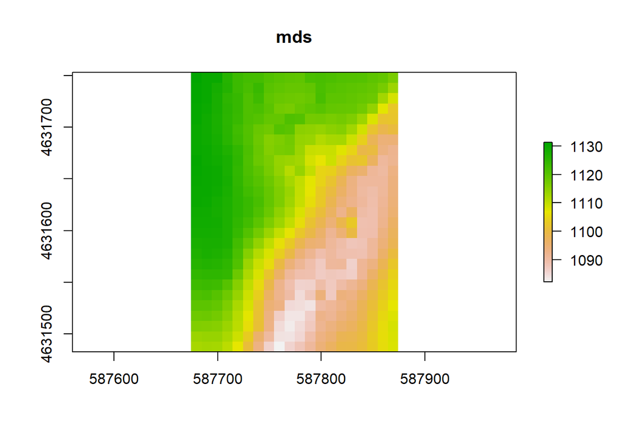

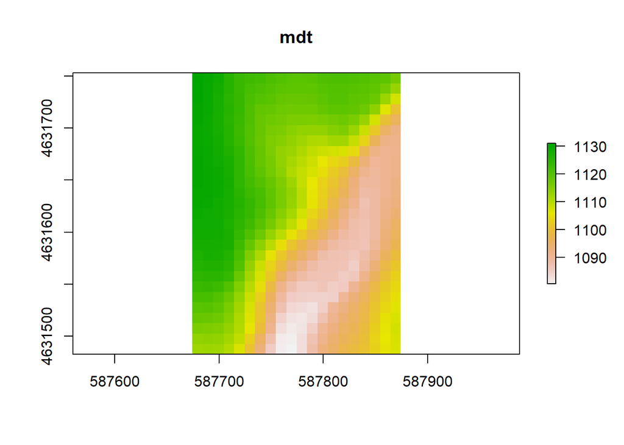

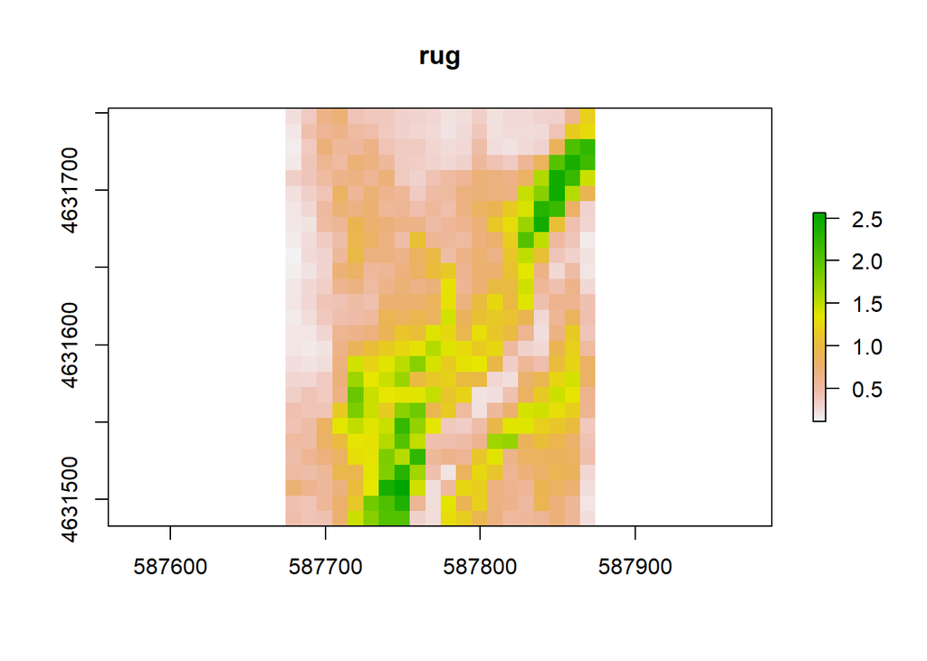

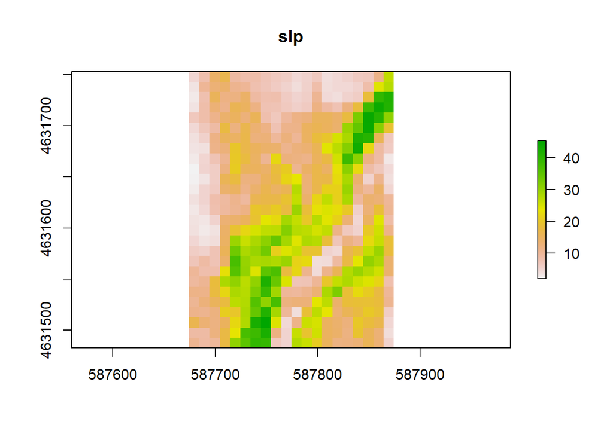

```r
for (i in 1:6) { # there are 6 bands
  # Select a band sequentially
  r<-agg[[i]]
  # Plot the selected band
  plot(r,main=r@data@names)
  # Get name of the band
  name<-r@data@names
  # export the raster to a folder using paste
  writeRaster(r, filename=paste(path2agglayers,name,sep=''), format="ascii", overwrite=TRUE)
}
```

# 2 Clipping Rasters

Load libraries

```r
library(raster)
library(maptools)
library(rgdal)
```

setting paths

```r
# path to aggregated layers
path2agglayers<-here("layers","lidar","aggregated_vars")
# clipping shapefile
path2clipshp<-here("layers","lidar","clipping_area.shp")
# path to clipped layers
path2cliplayers<-here("layers","lidar","clipped_vars")
```

Load environmental variables

```r
layers<-list.files(path=path2agglayers,pattern='asc',full.names=TRUE)
```

## 2.1 Join all rasters in a single object

```r
egv<-stack(layers)
```

## 2.2 check the structure of the rasters

```r
print(egv)
```

```
## class      : RasterStack
## dimensions : 27, 20, 540, 6  (nrow, ncol, ncell, nlayers)
## resolution : 10, 10  (x, y)
## extent     : 587674, 587874, 4631483, 4631753  (xmin, xmax, ymin, ymax)
## crs        : NA
## names      : asp, mda, mds, mdt, rug, slp
```

## 2.3 check descriptive statistics of the rasters

```r
summary(egv)
```

```
##              asp   mda      mds      mdt       rug       slp
## Min.    0.868781  0.00 1082.225 1080.525 0.1087100  2.028029
## 1st Qu. 1.913475  0.05 1096.248 1094.740 0.4210865  9.184954
## Median  2.382286  0.26 1111.180 1110.575 0.6727450 14.748836
## 3rd Qu. 3.329767  1.29 1120.943 1120.303 1.1279975 23.781116
## Max.    5.561549 15.01 1131.360 1131.000 2.5648689 45.348747
## NA's    0.000000  0.00    0.000    0.000 0.0000000  0.000000
```

## 2.4 Plot the stack

call x11() if the following plot is not represented correctly: with x11 a new window is open

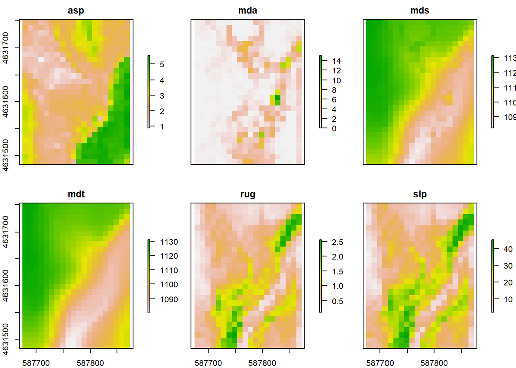

```r
plot(egv)
```

## 2.5 Load study area shapefile

```r
shp<-readOGR(path2clipshp)
```

# 3 Plot the shapefile

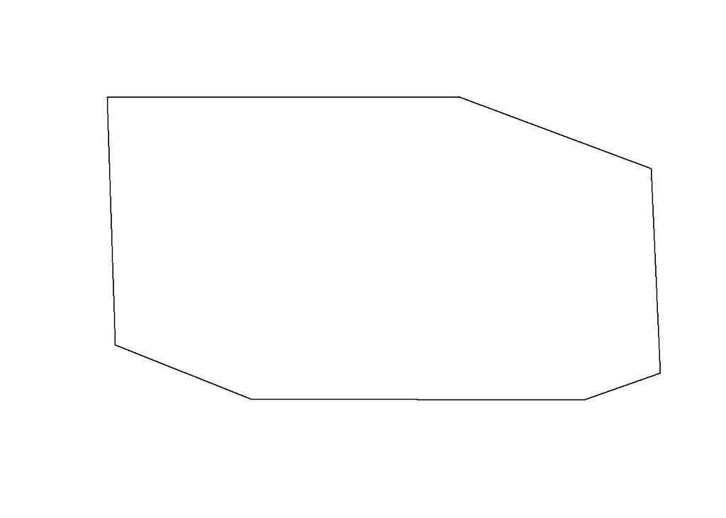

```r
plot(shp)
```

# 4 Loop to clip each raster sequentially

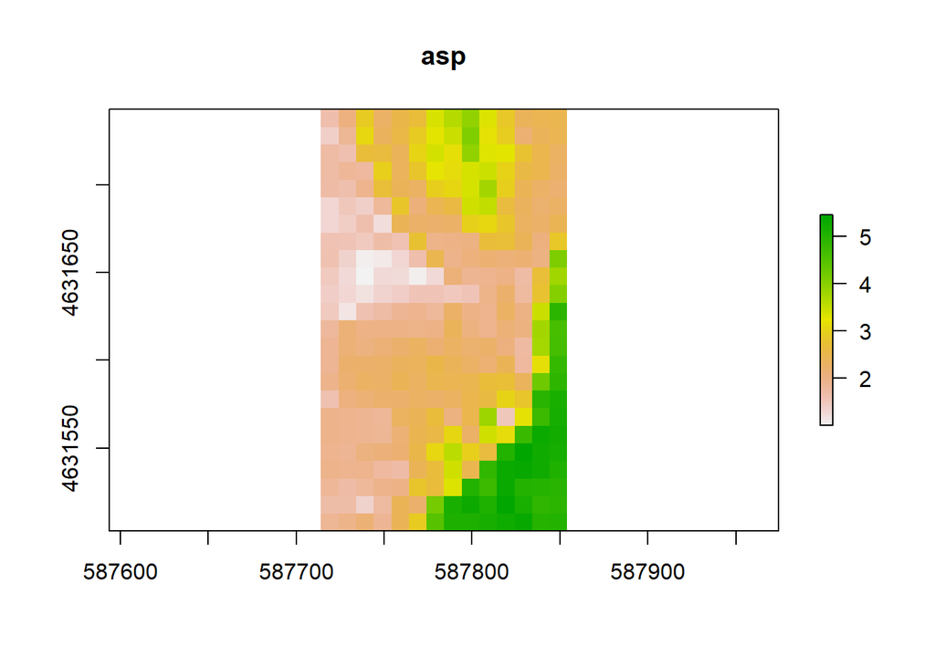

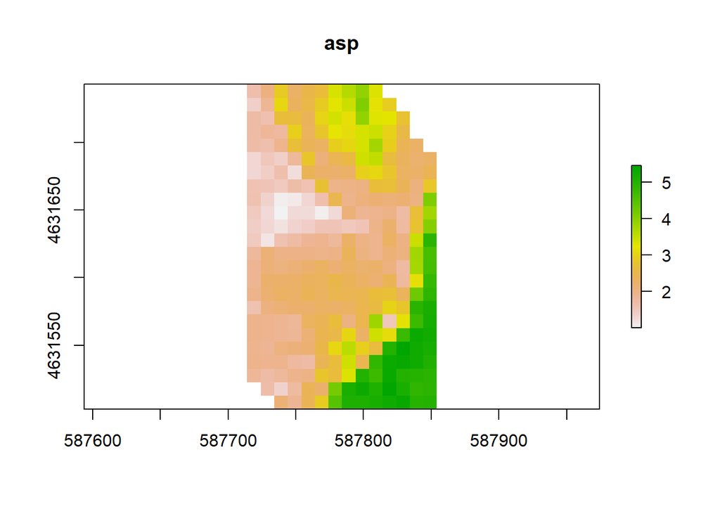

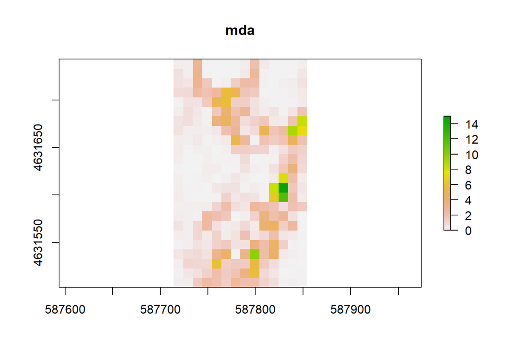

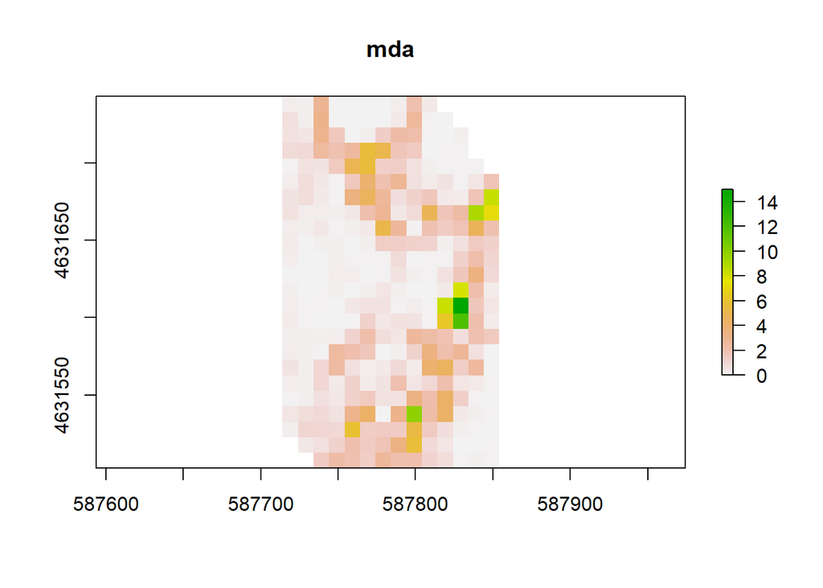

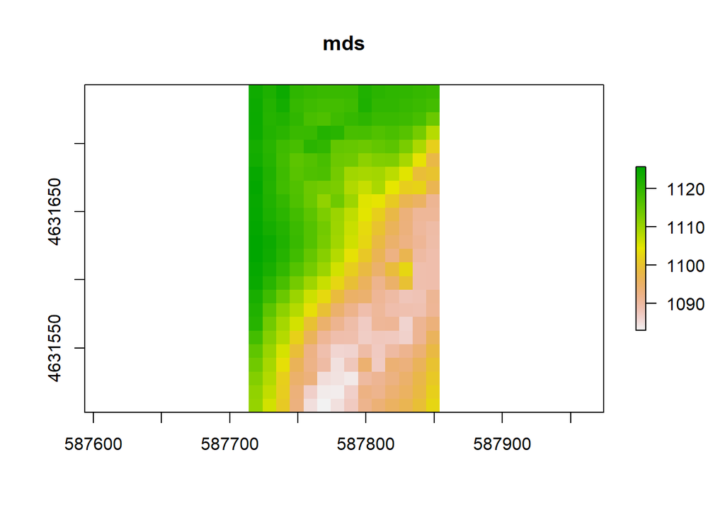

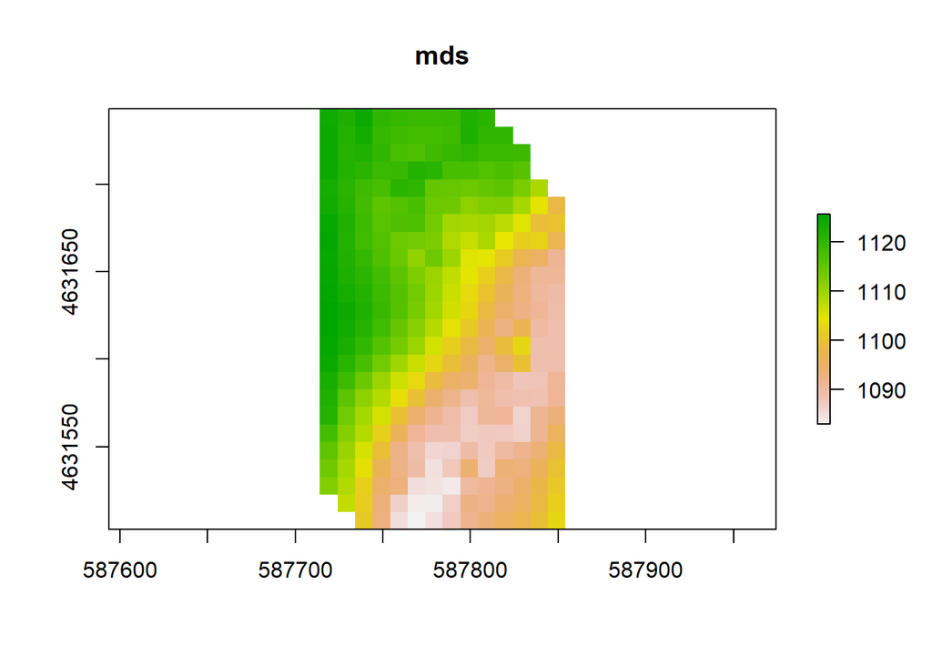

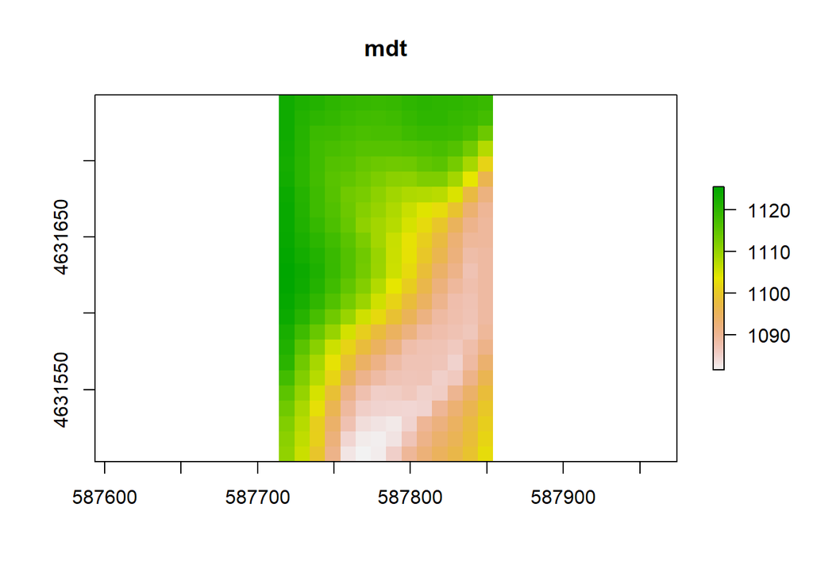

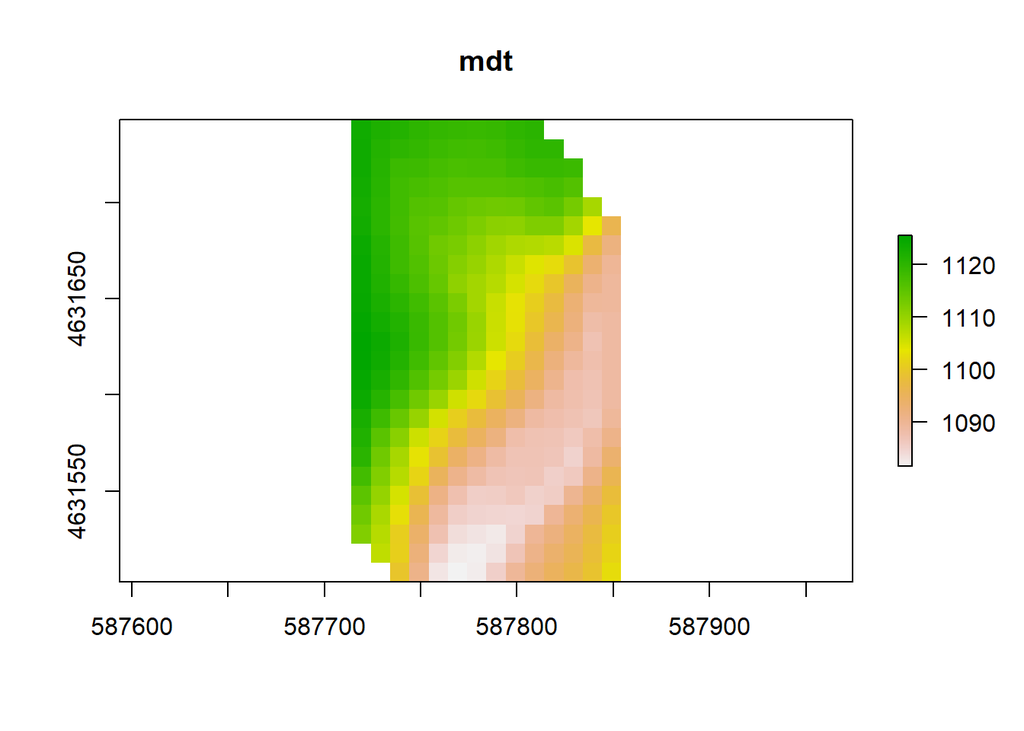

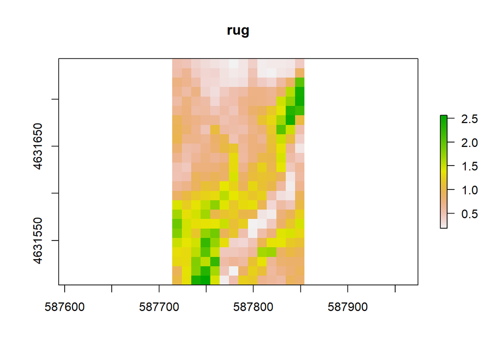

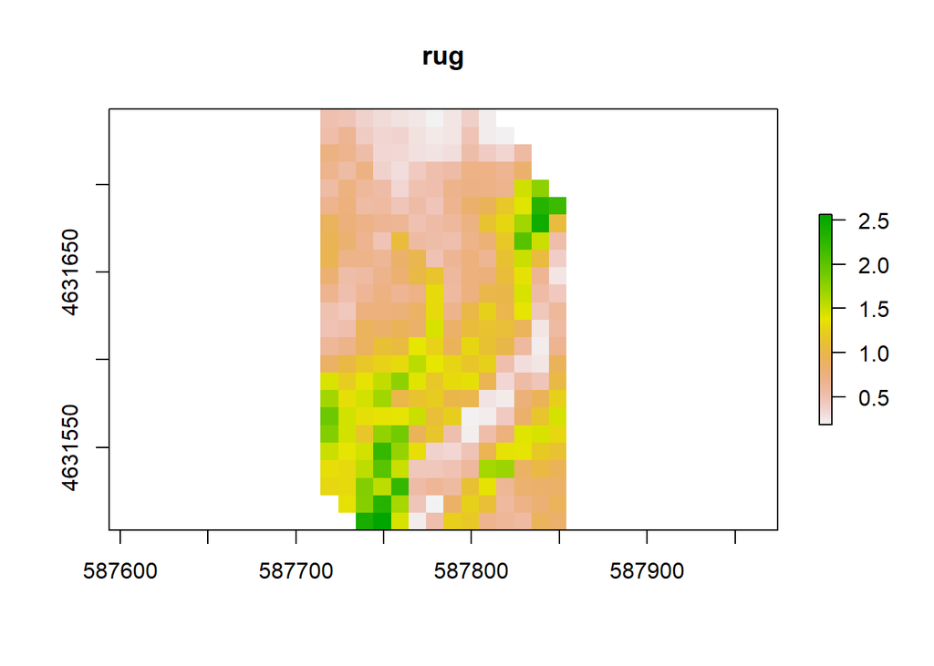

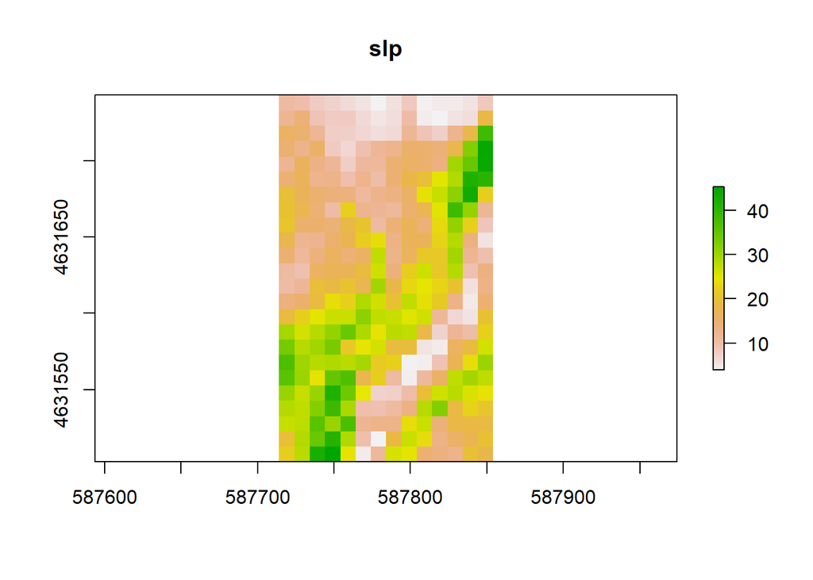

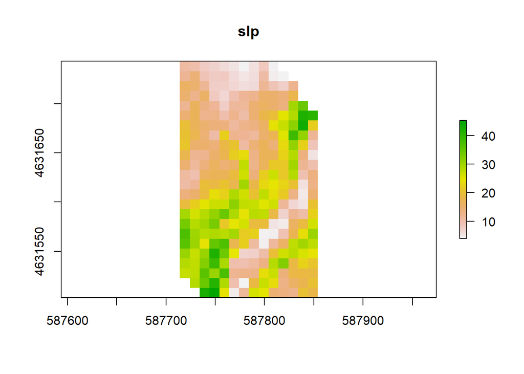

```r
for (i in layers) { # look for each ascii file in layers
  #load raster
  egv.i<-raster(i)
  # clip raster
  # the raster to be clipped; the clipping feature; snap determines in which direction the extent should be aligned
  # to the nearest border, inwards or outwards
  clip.r<-crop(egv.i, shp, snap="in")
  # plot the clipped raster
 # X11()
  plot(clip.r,main=clip.r@data@names)
  #mask raster with the shapefile to create NoData
  mask.r<-mask(clip.r, shp)
  # plot the masked raster
  #X11()
  plot(mask.r,main=mask.r@data@names)
  # Get name of the band
  name<-mask.r@data@names
  # export the raster to a folder using paste
  writeRaster(mask.r,paste(path2cliplayers,"clip_",name,sep=''),format="ascii", overwrite=TRUE)
}
```

## 4.1 plot all clipped variables

```r
files<-list.files(path=path2cliplayers,pattern='asc',full.names=TRUE)
# Join all rasters in a single object
clips<-stack(files)
```

## 4.2 Plot the stack

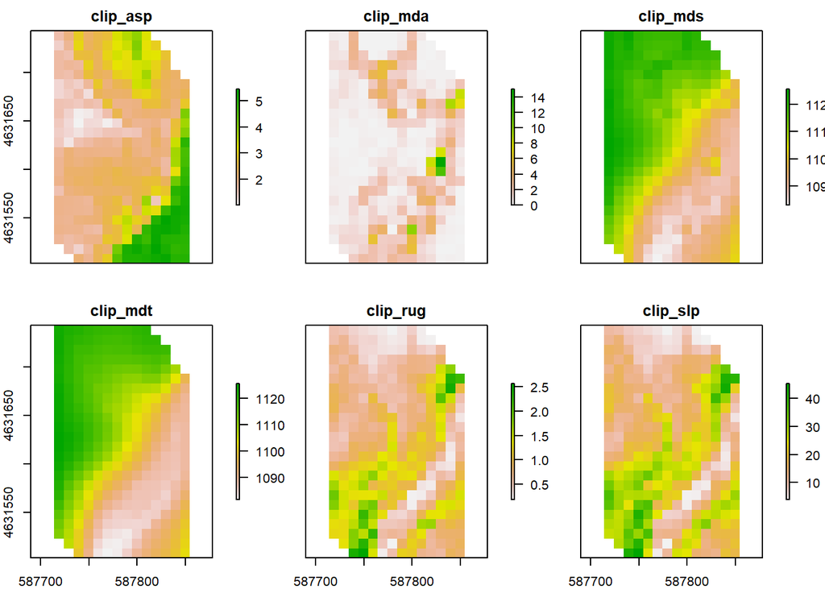

```r
plot(clips)
```

# 5 Load libraries

# 6 Set your paths

# 7 path to clipped layers

# 8 Load environmental variables

# 9 Calculate Pearson’s correlation among variables

# 10 Pearson’s correlation is parametric

# 11 Transform correlation results in a dataframe

# 12 Transfrom correlation matrix to distances

# 13 Load library to read species shapefiles and rasters

# 14 Set your paths

# 15 path to species folder

# 16 path to species shapefiles